# Missing Data Modeled

March 23, 2016

## About Me

- Moved to the Twin Cities about one year ago
- Masters in Applied Economics from UND
- Research Data Analyst at Allina Health
- Very new to data science

@github: datamused

@LinkedIn: www.linkedin.com/in/patrickdmobley

[figure not shown]

## The data

Iris Data Set

- Setosa
- Versicolour
- Virginica

50 observations each

## Why is missing data a problem?

Loss of power

```
##   Sepal.Length Sepal.Width Petal.Length Petal.Width Species
## 1          5.1         3.5          1.4         0.2  setosa
## 2          4.9         3.0          1.4         0.2  setosa
## 3          4.7         3.2          1.3         0.2  setosa
## 4          4.6         3.1          1.5         0.2  setosa
## 5          5.0         3.6          1.4         0.2  setosa
## 6          5.4         3.9          1.7         0.4  setosa
```

```
##   Sepal.Length Sepal.Width Petal.Length Petal.Width Species
## 1          4.3         3.0          1.1          NA  setosa
## 2          4.4         3.0          1.3         0.2  setosa
## 3          4.4         3.2          1.3         0.2  setosa
## 4          4.5         2.3          1.3         0.3  setosa
## 5          4.6         3.1          1.5         0.2    <NA>
## 6          4.6         3.2           NA         0.2  setosa
```

- 6.8% of the data is missing.
- However, only 117 complete rows (78%) are left.

Even small amounts of missing data, can result in large data loss.

## Visualizing the problem

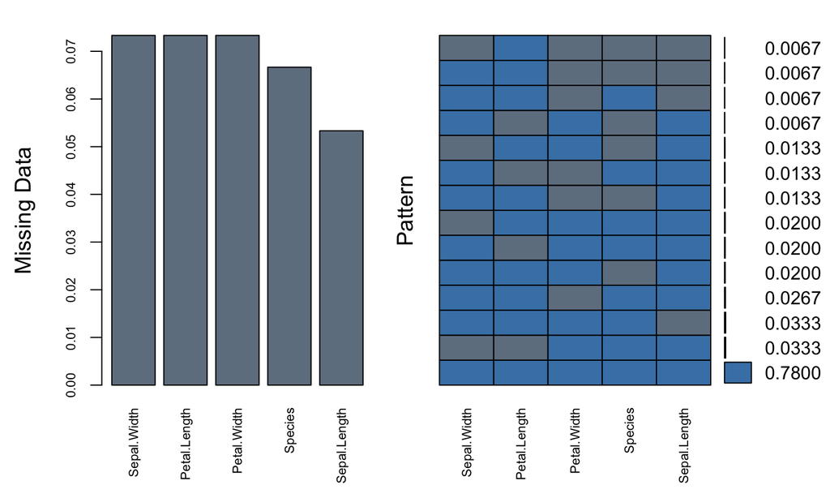

```
##
##  Variables sorted by number of missings:
##      Variable      Count
##   Sepal.Width 0.07333333
##  Petal.Length 0.07333333
##   Petal.Width 0.07333333
##       Species 0.06666667
##  Sepal.Length 0.05333333
```

```r
#install.packages("VIM")
require(VIM)
aggr(iris.mis, col=c('steelblue','slategrey'),numbers=TRUE,sortVars=TRUE,
    labels=names(iris.mis),cex.axis=.7,gap=3,ylab=c("Missing Data","Pattern"))
```

Bias

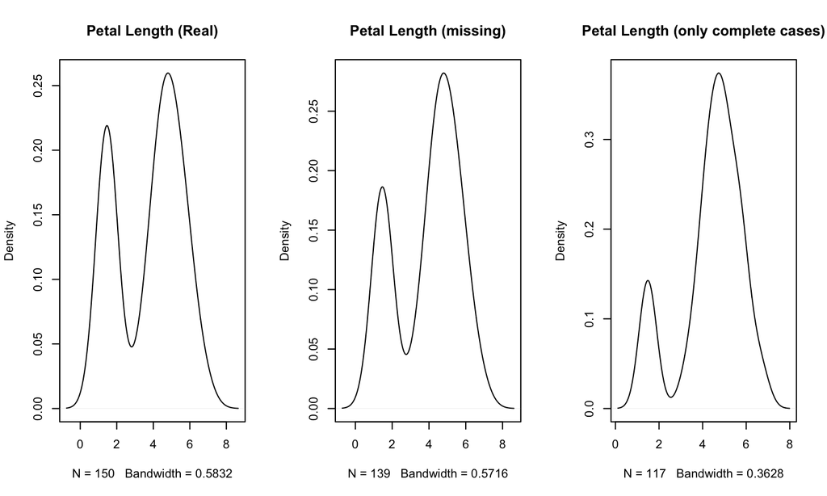

## Goals for Missing Data Models

1. Minimize bias.
2. Maximize the use of available information.
3. Yield good estimates of uncertainty.

Taken from Paul Allison's chapter on missing data referenced at end of presentation.

## Three types of missing data

- MCAR - Missing Completely At Random
- MAR - Missing At Random
- MNAR - Missing Not At Random

They each have different implications.

## Methods to deal with missing data

- Deletion
  - Listwise
  - Pairwise
- Imputation
  - Mean
  - Median
  - More complex methods

## Keep in Mind

> All models are wrong, but some are useful

```
  — famed statistician George Box
```

## Missing Data Packages in R

- Imputation
  - Hmisc
  - [missForest](https://stat.ethz.ch/education/semesters/ss2013/ams/paper/missForest_1.2.pdf)
  - [MICE](https://www.jstatsoft.org/index.php/jss/article/view/v045i03/v45i03.pdf)
  - [Amelia](https://cran.r-project.org/web/packages/Amelia/vignettes/amelia.pdf)
- Tools and visulaization
  - mitools
  - [VIM](http://www.statistik.tuwien.ac.at/forschung/CS/CS-2008-1complete.pdf)

## Example in Hmisc

```r
#install.packages("Hmisc")
require(Hmisc)
```

`impute()` function replaces the missing value with user defined statistical method (default=median | mean | max etc.)

```r
iris.mis$imputed.Petal.Length <-
              with(iris.mis, impute(Petal.Length, mean))
iris.mis$imputed.Petal.Width <-
              with(iris.mis, impute(Petal.Width, mean))
```

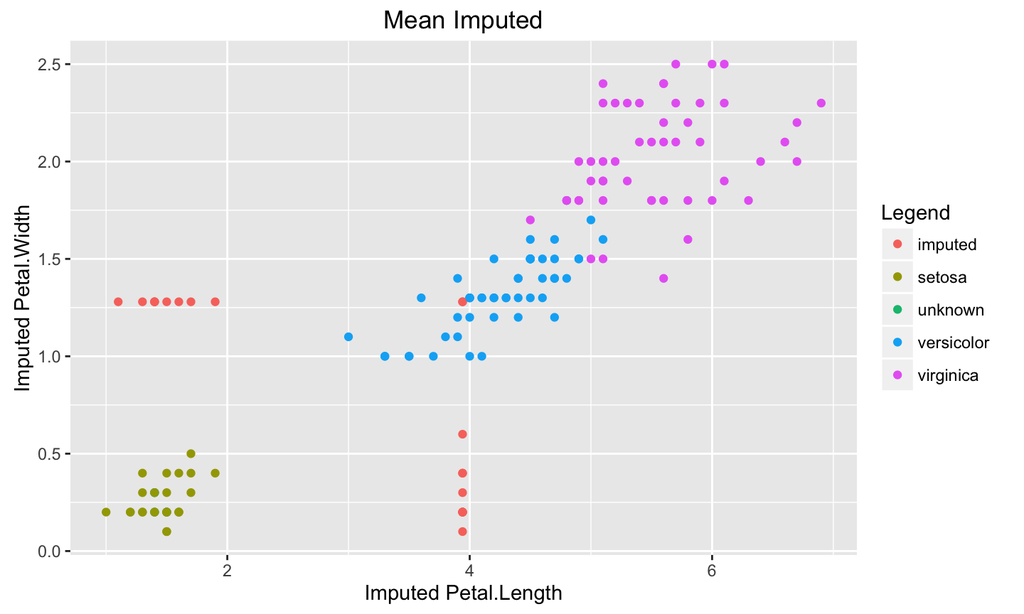

`aregImpute()` function creates multiple imputations using additive regression, bootstrapping, and predictive mean matching.

```r
imputed_aregImpute <- aregImpute(~ Sepal.Length + Sepal.Width
                        + Petal.Length + Petal.Width + Species,
                        data = iris.mis, n.impute = 5)
```

5 separate imputations to yield good estimates of uncertainty. The literature suggests 20 or more imputations.

```r
imputed <- as.data.frame(impute.transcan(imputed_aregImpute,
                           imputation = 1, data = iris.mis,
                           list.out = TRUE, pr=FALSE, check=FALSE))
```

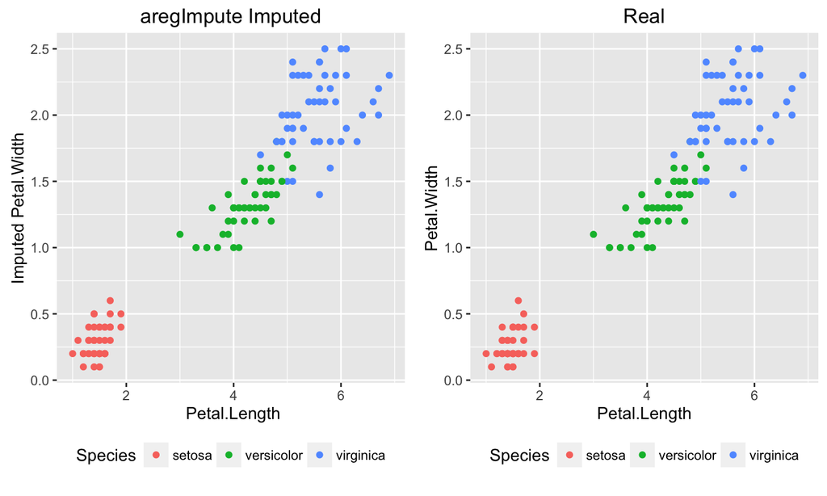

## Example in MICE

MICE stands for Multiple Imputation using Chained Equations

```r
#install.packages("mice")
require(mice)
imputed_mice <- mice(data = iris.mis[1:5], m = 5,
                  method = "pmm", maxit=50, seed=500)
```

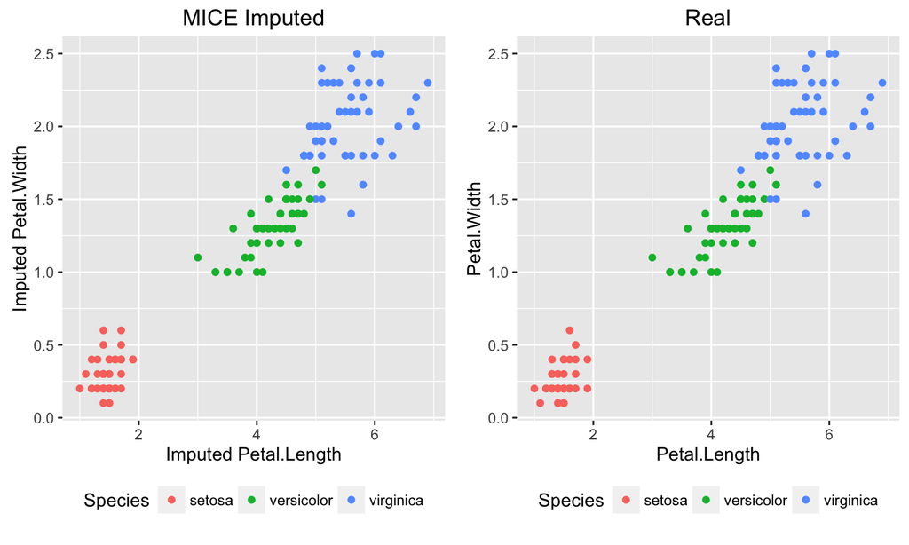

## Example in missForest

```r
#install.packages("missForest")
require(missForest)
```

missForest uses an iterative random forest approach to missing data.

It accomplishes this by estimating the accuracy of these predictions and adjusts the model.

It can also run as parallel process when installing the package doParallel

Imputing with missForest:

```r
#install.packages("doParallel")
require(doParallel)
registerDoParallel()                    #registering the processor
getDoParWorkers()                       #number of processors running
#vignette("gettingstartedParallel")     #for more information
imputed_forest <- missForest(iris.mis[1:5], parallelize = "forest")
imputed_forest$OOBerror                 #calling Out Of Bag error
iris.mis.forest <- imputed_forest$ximp
```

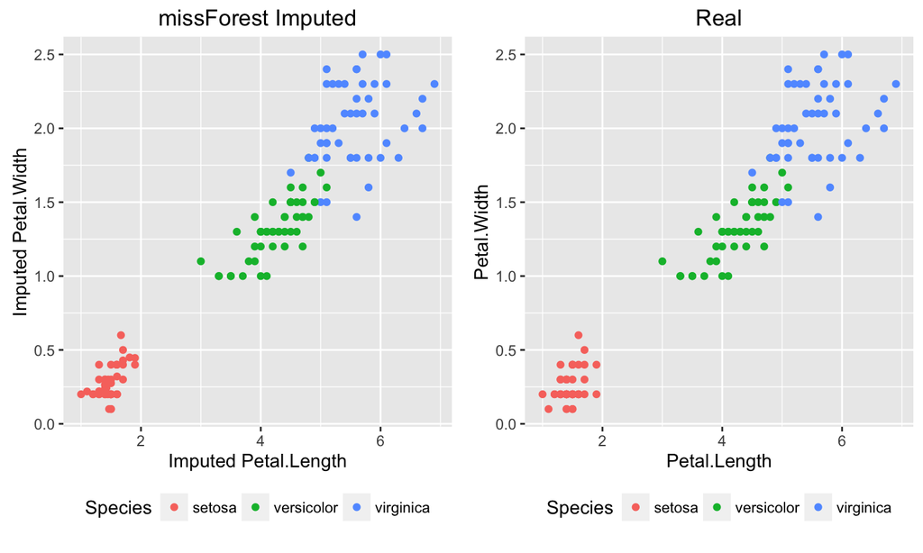

## Questions

[figure not shown]

## Resources

This presentation:

https://github.com/datamused/Missing-Data

Articles:

http://www.analyticsvidhya.com/blog/2016/03/tutorial-powerful-packages-imputing-missing-values/

http://www.analyticsvidhya.com/blog/2016/01/guide-data-exploration/

Chapters:

http://www.stats.ox.ac.uk/~snijders/Graham2009.pdf

http://www.statisticalhorizons.com/wp-content/uploads/2012/01/Milsap-Allison.pdf